# Beschreibung

Das Ziel der Arbeit ist es, die die täglichen Umsätze aller 1.115 Filialen der Dirk Rossmann GmbH in Deutschland für einen Zeitraum von sechs Wochen vorherzusagen. Dazu werden die Verkaufsdaten der Filialen zunächst deskriptiv analysiert. Verschiedenen Faktoren wie Sonderangebote, Wettbewerb, Schul- und Feiertage, Saisonabhängigkeit und Standort der Filialen sind für die Umsätze bedeutend und werden dahingehend berücksichtigt. Die Grundlage der Untersuchung bildet der Rossmann Store Sales Datensatz, der im Rahmen eines Wettbewerbs auf der Plattform Kaggle veröffentlich wurde. Dieser Datensatz besteht aus drei Comma-Separated-Values-(CSV)-Tabellen: train.csv, test.csv und store.csv. Die train.csv enthält historische Verkaufsdaten, während die test.csv historische Daten ohne Verkäufe beinhaltet. Die store.csv ergänzt diese Daten um zusätzliche Informationen zu den 1.115 Filialen.

Die Datentypen in den Datensätzen werden hier einmalig mit den entsprechenden Wertebereichen angegeben:

- int64 (8 Bytes): -9.223.372.036.854.775.808 bis 9.223.372.036.854.775.807
- float64 (8 Bytes): -1.7976931348623157e+308 bis 1.7976931348623157e+308
- datetime64 (8 Bytes): 0:00:00 (Mitternacht), 1. Januar 0001 bis 23:59:59, 31. Dezember 9999
- object (4 Bytes auf einer 32.Bit Plattform; 8 Bytes auf einer 64-Bit-Plattform) (Microsoft Coorperation, o.D.)

```python
import pandas as pd
import seaborn as sns
import matplotlib.pyplot as plt
```

```python
file_store = "../data/store.csv"
file_train = "../data/train.csv"
file_test = "../data/test.csv"
```

```python
df_store = pd.read_csv(file_store, delimiter=",", encoding="latin", header=0, thousands=",", decimal='.', low_memory=False)
df_train = pd.read_csv(file_train, delimiter=",", encoding="latin", header=0, thousands=",", decimal='.', low_memory=False)
df_test = pd.read_csv(file_test, delimiter=",", encoding="latin", header=0, thousands=",", decimal='.', low_memory=False)
```

```python
pd.set_option('display.float_format', '{:.2f}'.format)
```

# Datenanalyse Store

Die store.csv Datei hat insgesamt 1.115 Zeilen und 10 Spalten, d.h. es gibt 1.115 Filialen der Dirk Rossmann GmbH.

Die Datenfelder der store.csv sind:

Store

- eindeutige ID für jeden Store
- dtype: int64
- unique values: 1, 2, 3, ..., 1113, 1114, 1115

StoreTypes

- Typ des Stores: a, b, c, d
- dtype: object
- unique values: 'a', 'b', 'c', 'd'

Assortment

- Sortiementsstufe
- a = Basic, b = extra, c = erweitert
- dtype: object
- unique values: 'a', 'b', 'c'

CompetitionDistance

- Entfernung in Metern zum nächsten Geschäft
- dtype: float64 --> Int64
- unique values: 20 - 75860

CompetitionOpenSinceMonth

- Monatsangabe, in dem das nächste konkurrierende Geschäft eröffnet wurde
- dtype: float64 --> Int64
- unique values: 1, 2, 3, 4, 5, 6, 7, 8, 9, 10, 11, 12,

CompetitionOpenSinceYear

- Jahresangabe, in dem das nächste konkurrierende Geschäft eröffnet wurde
- dtype: float64 --> Int64
- unique values: 1900, 1961, 1990, 1994, 1995 ,1998, 1999, 2000, 2001, 2002, 2003, 2004, 2005 ,2006, 2007, 2008, 2009, 2010, 2011, 2012, 2013, 2014, 2015,

Promo2

- gibt an, ob eine fortlaufende Aktion im Geschäft stattfindet
- 0 = Filiale nimmt nicht teil, 1 = Filiale nimmt teil
- dtype: int64
- unique values: 0, 1

Promo2SinceWeek

- Kalenderwoche, in der das Geschäft mit der Teilnahme an Promo2 begonnen hat
- dtype: float64 --> Int64
- unique values: 1, 5, 6, 9, 10, 13, 14, 18, 22, 23, 26, 27, 28, 31, 35, 36, 37, 39, 40, 44, 45, 48, 49, 50,

Promo2SinceYear

- Jahr, in der das Geschäft mit der Teilnahme an Promo2 begonnen hat
- dtype: float64 --> Int64
- unique values: 2009, 2010, 2011, 2012, 2013, 2014, 2015,

PromoInterval

- Intervalle, in denen Promo2 gestartet wird und gibt die Monate an, in denen die Aktion neu gestartet wird
- Bsp.: Das Intervall „Feb,Mai,Aug,Nov“ bedeutet, dass jede Aktionsrunde im Februar, Mai, August und November beginnt
- dtype: object
- unique values: nan, 'Jan,Apr,Jul,Oct', 'Feb,May,Aug,Nov', 'Mar,Jun,Sept,Dec'

Es gibt somit 5 Datenfeld des Typs float64, 2 Datenfelder des Typs int64 und 3 Datenfelder des Typs object. Aufgrund der Werte in den Spalten `CompetitionDistance`, `CompetitionOpenSinceMonth`, `CompetitionOpenSinceYear`, `Promo2SinceWeek` und `Promo2SinceYear` werden die Datentypen jeweils in ein Integer Array umgewandelt. Die Umwandlung der Datentypen ist in der Liste Datenfelder durch Pfeile markiert.

```python
df_store.head()
```

|  | Store | StoreType | Assortment | CompetitionDistance | CompetitionOpenSinceMonth | CompetitionOpenSinceYear | Promo2 | Promo2SinceWeek | Promo2SinceYear | PromoInterval |
| --- | --- | --- | --- | --- | --- | --- | --- | --- | --- | --- |
| 0 | 1 | c | a | 1270.00 | 9.00 | 2008.00 | 0 | NaN | NaN | NaN |
| 1 | 2 | a | a | 570.00 | 11.00 | 2007.00 | 1 | 13.00 | 2010.00 | Jan,Apr,Jul,Oct |
| 2 | 3 | a | a | 14130.00 | 12.00 | 2006.00 | 1 | 14.00 | 2011.00 | Jan,Apr,Jul,Oct |
| 3 | 4 | c | c | 620.00 | 9.00 | 2009.00 | 0 | NaN | NaN | NaN |
| 4 | 5 | a | a | 29910.00 | 4.00 | 2015.00 | 0 | NaN | NaN | NaN |

```python
df_store.shape
```

```
(1115, 10)
```

```python
df_store.info()
```

```
<class 'pandas.core.frame.DataFrame'>
RangeIndex: 1115 entries, 0 to 1114
Data columns (total 10 columns):
 #   Column                     Non-Null Count  Dtype
---  ------                     --------------  -----
 0   Store                      1115 non-null   int64
 1   StoreType                  1115 non-null   object
 2   Assortment                 1115 non-null   object
 3   CompetitionDistance        1112 non-null   float64
 4   CompetitionOpenSinceMonth  761 non-null    float64
 5   CompetitionOpenSinceYear   761 non-null    float64
 6   Promo2                     1115 non-null   int64
 7   Promo2SinceWeek            571 non-null    float64
 8   Promo2SinceYear            571 non-null    float64
 9   PromoInterval              571 non-null    object
dtypes: float64(5), int64(2), object(3)
memory usage: 87.2+ KB
```

```python
#change data type
df_store = df_store.astype({"CompetitionDistance": 'Int64', "CompetitionOpenSinceMonth": 'Int64', "CompetitionOpenSinceYear": 'Int64', "Promo2SinceWeek": 'Int64', "Promo2SinceYear": 'Int64'})
```

```python
df_store['Store'].unique()
```

```
array([   1,    2,    3, ..., 1113, 1114, 1115], dtype=int64)
```

```python
df_store['StoreType'].unique()
```

```
array(['c', 'a', 'd', 'b'], dtype=object)
```

```python
df_store['Assortment'].value_counts()
```

```
Assortment
a    593
c    513
b      9
Name: count, dtype: int64
```

```python
df_store['Assortment'].unique()
```

```
array(['a', 'c', 'b'], dtype=object)
```

```python
df_store['CompetitionOpenSinceMonth'].unique()
```

```
<IntegerArray>
[9, 11, 12, 4, 10, 8, <NA>, 3, 6, 5, 1, 2, 7]
Length: 13, dtype: Int64
```

```python
df_store['CompetitionOpenSinceYear'].unique()
```

```
<IntegerArray>
[2008, 2007, 2006, 2009, 2015, 2013, 2014, 2000, 2011, <NA>, 2010, 2005, 1999,
 2003, 2012, 2004, 2002, 1961, 1995, 2001, 1990, 1994, 1900, 1998]
Length: 24, dtype: Int64
```

```python
df_store['Promo2'].unique()
```

```
array([0, 1], dtype=int64)
```

```python
df_store['Promo2SinceWeek'].unique()
```

```
<IntegerArray>
[<NA>,   13,   14,    1,   45,   40,   26,   22,    5,    6,   10,   31,   37,
    9,   39,   27,   18,   35,   23,   48,   36,   50,   44,   49,   28]
Length: 25, dtype: Int64
```

```python
df_store['Promo2SinceYear'].unique()
```

```
<IntegerArray>
[<NA>, 2010, 2011, 2012, 2009, 2014, 2015, 2013]
Length: 8, dtype: Int64
```

```python
df_store['PromoInterval'].unique()
```

```
array([nan, 'Jan,Apr,Jul,Oct', 'Feb,May,Aug,Nov', 'Mar,Jun,Sept,Dec'],
      dtype=object)
```

Insgesamt gibt es 2.343 fehlerhafte Werte in der Datei store.csv. In der Spalte `CompetitionDistance` sind 3 Werte fehlerhaft, in der Spalte `CompetitionOpenSinceMonth` 354 Werte und in der Spalte `CompetitionDistanceYear` ebenfalls 354 Werte. Die Spalten `Promo2SinceWeek`, `Promo2SinceYear` und `PromoInterval` weisen jeweils 544 fehlerhafte Werte auf. Die drei fehlerhaften Werte der Spalte `CompetitionDistance` sind zur beispielhaften Darstellung in einer Tabelle dargestellt.

```python
df_store.isna().sum().sum()
```

```
2343
```

```python
df_store.isna().sum()
```

```
Store                          0
StoreType                      0
Assortment                     0
CompetitionDistance            3
CompetitionOpenSinceMonth    354
CompetitionOpenSinceYear     354
Promo2                         0
Promo2SinceWeek              544
Promo2SinceYear              544
PromoInterval                544
dtype: int64
```

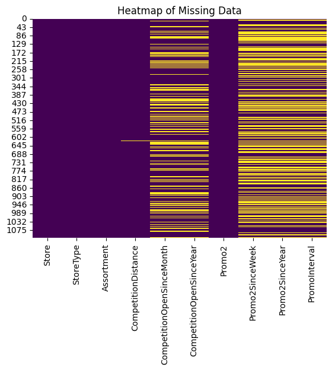

```python
sns.heatmap(df_store.isnull(), cbar=False, cmap='viridis')
plt.title('Heatmap of Missing Data')
plt.show()
```

```python
df_store[df_store['CompetitionDistance'].isnull()]
```

|  | Store | StoreType | Assortment | CompetitionDistance | CompetitionOpenSinceMonth | CompetitionOpenSinceYear | Promo2 | Promo2SinceWeek | Promo2SinceYear | PromoInterval |
| --- | --- | --- | --- | --- | --- | --- | --- | --- | --- | --- |
| 290 | 291 | d | a | <NA> | <NA> | <NA> | 0 | <NA> | <NA> | NaN |
| 621 | 622 | a | c | <NA> | <NA> | <NA> | 0 | <NA> | <NA> | NaN |
| 878 | 879 | d | a | <NA> | <NA> | <NA> | 1 | 5 | 2013 | Feb,May,Aug,Nov |

Die describe-Funktion liefert eine statistische Zusammenfassung der Spalten des Store Datensatzes. Aufgrund das einige Merkmale des Store-Datensatzes qualitativ sindm, können diese nicht mit der describe-Methode betrachtet werden. Es werden die numerischen Spalten `CompetitionDistance`, `CompetitionOpenSinceMonth`, `CompetitionOpenSinceYear`, `Promo2SinceWeek` und `Promo2SinceYear` untersucht. Mit der describe-Methode können die Nicht-Null-Werte (count), der Mittelwert (mean), die Standardabweichung (std), der Minimalwert (min), das 25%-Qunatil (25%), der Median (50%), das 75%-Quantil (75%) und der Maximalwert (max) je Spalte abgelesen werden. Die Spalte CompetitionDistance enthält 1.112 Werte, wobei wie schon zuvor festgestellt die drei fehlenden Werte NaN-Werte sind. Die durschnittliche Distanz zu einer weiteren Wettbewerber-Filiale beträgt 5.404,90 m mit einer Standardabweichung von 7.663,17 m. Die minimale Entfernung zur Konkurrenz sind 20 m und die maximale Entfernung 75860 m. 25 % der Filialen haben eine Konkurrenz in einer Entfernung von weniger als 717,50 m und 75 % der Filialen haben eine Entfernung von weniger als 6882,50 m. Der Median liegt bei 2.325 m. Durch die Spalten `CompetitionOpenSinceMonth` und `CompetitionOpenSinceYear` wird Wettbewerbssituation näher erläutert. Bei jeweils beiden Spalten fehlen, wie schon bereits festgestellt, 354 Werte. Der durchschnittliche Monat in dem ein Wettbewerb eröffnet wurde liegt im Juli und im Jahr 2008. Die Standardabweichungen liegen bei den Monaten bei 3,21 und bei den Jahren bei 6,20. Der früheste Monat für die Eröffnung eines Wettberwerbs ist der Januar und der letzte ist Dezember. Das erste Jahr in dem eine Wettbewerber-Filiale hinzukam war das Jahr 1900 und die letzte im Jahr 2015. Aufgrund der Gründung des Unternehmens 1972 (Dirk Rossmann GmbH, o.D.) deutet der minimale Wert auf einen Fehler hin. 25 % der Eröffnungen fanden im oder vor April und 75 % im oder vor dem Monat Oktober statt. Der Median ist der Monat August. Hinsichtlich der Jahre fanden 25 % der Eröffnungen im Datensatz im oder vor dem Jahr 2006 statt und 75 % im oder vor dem Jahr 2013. Der Median liegt bei 2010.

Die Spalten `Promo2SinceWeek` und `Promo2SinceYear` geben an, in welcher Kalenderwoche und in welchem Jahr das erste Mal eine andauernde Promoaktion gestartet wurde. Die describe-Methode gibt weitere Aufschlüsse über die Verteilung der Daten. Bei beiden Spalten, wie ebenfalls schon festgestellt wurde, fehlen jeweils 544 Werte. Die durschnittliche Kalenderwoche in der `Promo2` begann ist die 24. Woche mit einer Standardabweichung von 14 Wochen. Die frühste Woche ist die erste Kalenderwoche und die späteste die 50-igste Kalenderwoche in der die Promo gestartet wurde. 25 % der `Promo2` sind in oder vor der 13. Kalenderwoche zu verzeichnen, während 75 % in oder vor der 37. Woche gestartet wurden. Der Median liegt in der 22. Kalenderwoche. Das Durchschnittjahr ist hierbei das Jahr 2011 mit einer Standardabweichung von 1,67 Jahren. Das früheste Jahr in der eine `Promo2` gestartet wurde ist das Jahr 2009 und der letzte Start fand 2015 statt. 25 % der `Promo2`-Start fanden im oder vor dem Jahr 2011 und 75 % im oder vor dem Jahr 2013 statt. Der Median ist das Jahr 2012.

```python
df_store[['CompetitionDistance', 'CompetitionOpenSinceMonth', 'CompetitionOpenSinceYear', 'Promo2SinceWeek', 'Promo2SinceYear']].describe()
```

|  | CompetitionDistance | CompetitionOpenSinceMonth | CompetitionOpenSinceYear | Promo2SinceWeek | Promo2SinceYear |
| --- | --- | --- | --- | --- | --- |
| count | 1112.00 | 761.00 | 761.00 | 571.00 | 571.00 |
| mean | 5404.90 | 7.22 | 2008.67 | 23.60 | 2011.76 |
| std | 7663.17 | 3.21 | 6.20 | 14.14 | 1.67 |
| min | 20.00 | 1.00 | 1900.00 | 1.00 | 2009.00 |
| 25% | 717.50 | 4.00 | 2006.00 | 13.00 | 2011.00 |
| 50% | 2325.00 | 8.00 | 2010.00 | 22.00 | 2012.00 |
| 75% | 6882.50 | 10.00 | 2013.00 | 37.00 | 2013.00 |
| max | 75860.00 | 12.00 | 2015.00 | 50.00 | 2015.00 |

# Datenanalyse Train

Die train.csv Datei besteht aus 1.017.209 Zeilen und 9 Spalten.

Die Datenfelder der train.csv sind:

Store

- eindeutige ID für jeden Store
- dtype: int64
- unique values: 1 - 1115

DayOfWeek

- Wochentag des Verkaufs
- dtype: int64
- unique values: 1, 2, 3, 4, 5, 6, 7

Date

- Datum des Verkaufs
- dtype: object --> datetime64[ns]
- unique values: 2013-01-01 00:00:00 - 2015-07-31 00:00:00

Sales

- Umsatz für einen bestimmten Tag
- dtype: int64
- unique values: 0 - 41551

Customers

- Anzahl der Kunden an einem Tag
- dtype: int64
- unique values: 0 - 7388

Open

- Indikator, ob das Geschäft geöffnet war
- 0 = geschlossen, 1 = geöffnet
- dtype: int64
- unique values: 1, 0

Promo

- Indikator, ob im Geschäft an diesem Tag eine Promo stattfindet
- dtype: int64
- unique values: 1, 0

StateHoliday

- Indikator, ob dieser Tag ein staatlicher Feiertag ist
- 0 = Keine, a = gesetzlicher Feiertag, b = Osterferien, c = Weihnachten
- dtype: object
- unique values: '0', 'a', 'b', 'c'

SchoolHoliday

- Indikator, ob das Geschäft von der Schließung öffentlicher Schulen betroffen war
- dtype: int64
- unique values: 1, 0

Insgesamt sind 7 Datenfelder vom Typ int64 und 2 vom Typ object. Aufgrund, dass es sich bei der Spalte `Date` um ein Datum handelt, wird der Datentyp von object zu datetime64[ns] umgewandelt. Die Umwandlung ist in der Liste Datenfelder durch den Pfeil erkennbar.

```python
df_train.shape
```

```
(1017209, 9)
```

```python
df_train.head()
```

|  | Store | DayOfWeek | Date | Sales | Customers | Open | Promo | StateHoliday | SchoolHoliday |
| --- | --- | --- | --- | --- | --- | --- | --- | --- | --- |
| 0 | 1 | 5 | 2015-07-31 | 5263 | 555 | 1 | 1 | 0 | 1 |
| 1 | 2 | 5 | 2015-07-31 | 6064 | 625 | 1 | 1 | 0 | 1 |
| 2 | 3 | 5 | 2015-07-31 | 8314 | 821 | 1 | 1 | 0 | 1 |
| 3 | 4 | 5 | 2015-07-31 | 13995 | 1498 | 1 | 1 | 0 | 1 |
| 4 | 5 | 5 | 2015-07-31 | 4822 | 559 | 1 | 1 | 0 | 1 |

```python
df_train.info()
```

```
<class 'pandas.core.frame.DataFrame'>
RangeIndex: 1017209 entries, 0 to 1017208
Data columns (total 9 columns):
 #   Column         Non-Null Count    Dtype
---  ------         --------------    -----
 0   Store          1017209 non-null  int64
 1   DayOfWeek      1017209 non-null  int64
 2   Date           1017209 non-null  object
 3   Sales          1017209 non-null  int64
 4   Customers      1017209 non-null  int64
 5   Open           1017209 non-null  int64
 6   Promo          1017209 non-null  int64
 7   StateHoliday   1017209 non-null  object
 8   SchoolHoliday  1017209 non-null  int64
dtypes: int64(7), object(2)
memory usage: 69.8+ MB
```

```python
df_train['Date'] = pd.to_datetime(df_train['Date'])
```

```python
df_train['Store'].unique()
```

```
array([   1,    2,    3, ..., 1113, 1114, 1115], dtype=int64)
```

```python
df_train['DayOfWeek'].unique()
```

```
array([5, 4, 3, 2, 1, 7, 6], dtype=int64)
```

```python
df_train['Date'].unique()
```

```
<DatetimeArray>
['2015-07-31 00:00:00', '2015-07-30 00:00:00', '2015-07-29 00:00:00',
 '2015-07-28 00:00:00', '2015-07-27 00:00:00', '2015-07-26 00:00:00',
 '2015-07-25 00:00:00', '2015-07-24 00:00:00', '2015-07-23 00:00:00',
 '2015-07-22 00:00:00',
 ...
 '2013-01-10 00:00:00', '2013-01-09 00:00:00', '2013-01-08 00:00:00',
 '2013-01-07 00:00:00', '2013-01-06 00:00:00', '2013-01-05 00:00:00',
 '2013-01-04 00:00:00', '2013-01-03 00:00:00', '2013-01-02 00:00:00',
 '2013-01-01 00:00:00']
Length: 942, dtype: datetime64[ns]
```

```python
df_train['Sales'].unique()
```

```
array([ 5263,  6064,  8314, ...,   660, 17815, 23303], dtype=int64)
```

```python
df_train['Customers'].unique()
```

```
array([ 555,  625,  821, ..., 3900,   36, 4065], dtype=int64)
```

```python
df_train['Open'].unique()
```

```
array([1, 0], dtype=int64)
```

```python
df_train['Promo'].unique()
```

```
array([1, 0], dtype=int64)
```

```python
df_train['StateHoliday'] = df_train['StateHoliday'].astype(str)
df_train['StateHoliday'].unique()
```

```
array(['0', 'a', 'b', 'c'], dtype=object)
```

```python
df_train['SchoolHoliday'].unique()
```

```
array([1, 0], dtype=int64)
```

Die Datei `train.csv` enthält keine fehlerhaften Werte.

```python
df_train.isna().sum().sum()
```

```
0
```

Die describe-Funktion wird für die Spalten `DayOfWeek`, `Sales` und `Customers` ausgeführt, da diese numerische Werte enthalten. In allen drei Spalten sind jeweils alle Werte vorhanden, wie schon die Analyse der fehlerhaften Werte gezeigt hat. Der durchschnittliche Wochentag im Datensatz ist der vierter, welche Donnerstag entspricht mit einer Standardabweichung von 2. Der erste Wochentag ist Montag und der letzte Sonntag. 25 % der Datenpunkte fallen auf oder vor den Dienstag und 75 % auf Samstag. Der Median ist Donnerstag. Die Durchschnitt der Umsätze liegt bei 5.773,82 € mit einer Standardabweichung von 3.849,93 €. Der minimale Umsatz sind 0 € und der maximale Umsatz liegt bei 41.551 €. 25 % der Umsätze liegen unter 3.727 € und 75 % liegen unter 7.856 €. Der Median liegt bei 5.744 €. Die durschnittliche Kundenanzahl pro Tag liegt bei 633,15 mit einer Standardabweichung von 464,41. Die minimale Kundenanzahl ist 0 und die maximale Kundenanzahl ist 7.388. 25 % der Kundenanzahl liegt unter 405 und 75 % der Daten liegen unter 837 Personen. Der Median der Kunden ist 609.

```python
df_train[['DayOfWeek', 'Sales', 'Customers']].describe()
```

|  | DayOfWeek | Sales | Customers |
| --- | --- | --- | --- |
| count | 1017209.00 | 1017209.00 | 1017209.00 |
| mean | 4.00 | 5773.82 | 633.15 |
| std | 2.00 | 3849.93 | 464.41 |
| min | 1.00 | 0.00 | 0.00 |
| 25% | 2.00 | 3727.00 | 405.00 |
| 50% | 4.00 | 5744.00 | 609.00 |
| 75% | 6.00 | 7856.00 | 837.00 |
| max | 7.00 | 41551.00 | 7388.00 |

# Datenanalyse Test

Die test.csv Datei besteht aus 41.088 Zeilen und 8 Spalten.

Die Datenfelder der train.csv sind:

Id

- eine ID
- dtype: int64
- unique values: 1, 2, 3, ..., 41086, 41087, 41088

Store

- eindeutige ID für jeden Store
- dtype: int64
- unique values: 1 - 1115

DayOfWeek

- Wochentag des Verkaufs
- dtype: int64
- unique values: 1, 2, 3, 4, 5, 6, 7

Date

Open

- Indikator, ob das Geschäft geöffnet war
- 0 = geschlossen, 1 = geöffnet
- dtype: float64 --> Int64
- unique values: 1, 0

Promo

- Indikator, ob im Geschäft an diesem Tag eine Promo stattfindet
- dtype: int64
- unique values: 1, 0

StateHoliday

- Indikator, ob dieser Tag ein staatlicher Feiertag ist
- 0 = Keine, a = gesetzlicher Feiertag, b = Osterferien, c = Weihnachten
- dtype: object
- unique values: '0', 'a', 'b', 'c'

SchoolHoliday

- Indikator, ob das Geschäft von der Schließung öffentlicher Schulen betroffen war
- dtype: int64
- unique values: 1, 0

Insgesamt sind 5 Datenfelder vom Typ int64, 1 vom Typ float64 und 2 vom Typ object. Aufgrund, dass es sich bei der Spalte `Date` um ein Datum handelt, wird der Datentyp von object zu datetime64[ns] umgewandelt. Ebenso wurde der Datentyp der Spalte `Open` von float64 zu Int64 umgewandelt. Die Umwandlung ist in der Liste Datenfelder durch den Pfeil erkennbar.

```python
df_test.head()
```

|  | Id | Store | DayOfWeek | Date | Open | Promo | StateHoliday | SchoolHoliday |
| --- | --- | --- | --- | --- | --- | --- | --- | --- |
| 0 | 1 | 1 | 4 | 2015-09-17 | 1.00 | 1 | 0 | 0 |
| 1 | 2 | 3 | 4 | 2015-09-17 | 1.00 | 1 | 0 | 0 |
| 2 | 3 | 7 | 4 | 2015-09-17 | 1.00 | 1 | 0 | 0 |
| 3 | 4 | 8 | 4 | 2015-09-17 | 1.00 | 1 | 0 | 0 |
| 4 | 5 | 9 | 4 | 2015-09-17 | 1.00 | 1 | 0 | 0 |

```python
df_test.info()
```

```
<class 'pandas.core.frame.DataFrame'>
RangeIndex: 41088 entries, 0 to 41087
Data columns (total 8 columns):
 #   Column         Non-Null Count  Dtype
---  ------         --------------  -----
 0   Id             41088 non-null  int64
 1   Store          41088 non-null  int64
 2   DayOfWeek      41088 non-null  int64
 3   Date           41088 non-null  object
 4   Open           41077 non-null  float64
 5   Promo          41088 non-null  int64
 6   StateHoliday   41088 non-null  object
 7   SchoolHoliday  41088 non-null  int64
dtypes: float64(1), int64(5), object(2)
memory usage: 2.5+ MB
```

```python
df_test['Date'] = pd.to_datetime(df_test['Date'])
df_test['Open'] = df_test['Open'].astype('Int64')
```

In dem Datensatz Test gibt es insgesamt elf fehlerhafte Werte, wobei alle in der Spalte `Open` zu finden sind. Die elf Werte werden in der Tabelle ausgegeben.

```python
df_test.isna().sum().sum()
```

```
11
```

```python
df_test.isna().sum()
```

```
Id                0
Store             0
DayOfWeek         0
Date              0
Open             11
Promo             0
StateHoliday      0
SchoolHoliday     0
dtype: int64
```

```python
df_test['Id'].unique()
```

```
array([    1,     2,     3, ..., 41086, 41087, 41088], dtype=int64)
```

```python
df_test['Open'].unique()
```

```
<IntegerArray>
[1, <NA>, 0]
Length: 3, dtype: Int64
```

```python
df_test['Open'].value_counts()
```

```
Open
1    35093
0     5984
Name: count, dtype: Int64
```

```python
df_test[df_test['Open'].isnull()]
```

|  | Id | Store | DayOfWeek | Date | Open | Promo | StateHoliday | SchoolHoliday |
| --- | --- | --- | --- | --- | --- | --- | --- | --- |
| 479 | 480 | 622 | 4 | 2015-09-17 | <NA> | 1 | 0 | 0 |
| 1335 | 1336 | 622 | 3 | 2015-09-16 | <NA> | 1 | 0 | 0 |
| 2191 | 2192 | 622 | 2 | 2015-09-15 | <NA> | 1 | 0 | 0 |
| 3047 | 3048 | 622 | 1 | 2015-09-14 | <NA> | 1 | 0 | 0 |
| 4759 | 4760 | 622 | 6 | 2015-09-12 | <NA> | 0 | 0 | 0 |
| 5615 | 5616 | 622 | 5 | 2015-09-11 | <NA> | 0 | 0 | 0 |
| 6471 | 6472 | 622 | 4 | 2015-09-10 | <NA> | 0 | 0 | 0 |
| 7327 | 7328 | 622 | 3 | 2015-09-09 | <NA> | 0 | 0 | 0 |
| 8183 | 8184 | 622 | 2 | 2015-09-08 | <NA> | 0 | 0 | 0 |
| 9039 | 9040 | 622 | 1 | 2015-09-07 | <NA> | 0 | 0 | 0 |
| 10751 | 10752 | 622 | 6 | 2015-09-05 | <NA> | 0 | 0 | 0 |

# Korrelation

Nachdem die Datensätze beschrieben und analysiert wurden, können die Korrelationen der Variablen untersucht werden. Dafür werden jeweils eine Korrealtionsmatrix für den Trainingsdatensatz und den Store-Datensatz erstellt. Diese Matrizen zeigen die Korrelationen innerhalb der jeweiligen Datensätze an. Anschließend werden die beiden Datensätze zusammengeführt, um Korrelationen zwischen den Datensätzen zu betrachten. Postive Werte zwischen den Variablen zeigen einen positiven Zusammenhang an, wobei der Wert 1 eine perfekte Korrelation darstellt. Negative Werte hingegen weisen auf einen negativen Zusammenhang hin, wobei der Wert -1 eine perfekte Korrelation darstellt. Ein Wert von 0 bedeutet, dass zwischen den Variablen kein Zusammenhang besteht.

## Korrelation des Trainingsdatensatzes

Die Korrelationsmatrix des Trainingsdatensatzes bietet ein Überblick über die Beziehungen zwischen den Variablen. Für die angemessene Darstellung der Variable `StateHoliday` wird diese durch One-Hot-Encoding in vier neue Variablen (`StateHoliday_0`, `StateHoliday_a`, `StateHoliday_b`, `StateHoliday_c`) aufgeteilt. Diese Variablen erhalten dadurch binäre Daten. One-Hot-Encoding ist jedoch in diesem Zusammenhang v.a. bei qualitativen Merkmalen mit Vorsicht zu benutzen, da dadurch binäre Spalten erzeugt werden, die unabhängig voneinander erscheinen, es jedoch nicht sind und so Informationen zu den Beziehungen der Merkmale zueinander verloren gehen. Fortführend kann die ursprüngliche Korrelation durch die Zerstreuung der Korrelationen über mehrere Variablen nur erschwert interpretiert werden.

In der Korrealtionsmatrix liegen sowohl positive als auch negative Korrealtionen vor. Die Variable `DayOfWeek` zeigt eine schwach negative Korrelation zu den Variablen `Sales`, `Customers`, `Open` und `Promo`. Hingegen weist `Sales` eine starke positive Korrelation mit `Customers` auf und eine stark bis mittlere positive Korrelation mit `Open` und `Promo`. Hinsichtlich der `StateHoliday`-Variablen ist zwischen `Sales` und `StateHoliday_0` eine schwach positive Korrelation zu erkennen, während `Sales` und `StateHoliday_a` eine schwach negative Korelation aufweisen. Des Weiteren korreliert `Customers` positiv mit `Open` und schwach positiv mit `Promo`. Die Korrelationen zwischen `Customers` und den `StateHoliday`-Variablen gleichen sich mit denen der `Sales`. Die Variable `Open` weist eine schwach positive Korrelation mit `Promo` und `StateHoliday_0` sowie eine schwach negative Korrelation mit `StateHoliday_a` auf. Ebenfalls korreliert die `StateHoliday_0` Variable stark negativ bis negativ mit den anderen Ausprägungen dieser Variable. Die weiteren Korrelationen weisen einen Wert von Null oder nahe Null auf, was darauf hinweist, dass kein Zusammenhang mit den anderen Variablen besteht.

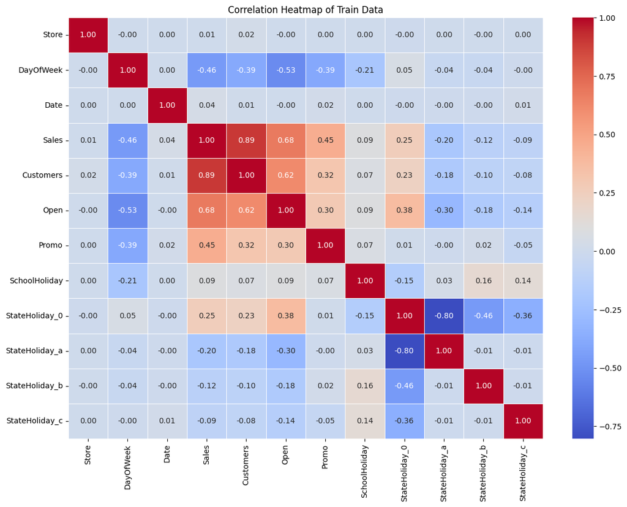

```python
#One-Hot-Encoding for StateHoliday
train_encoded = pd.get_dummies(df_train, columns=['StateHoliday'])

# Correlation matrix for train data
correlation_matrix = train_encoded.corr()

# Plotting the correlation heatmap
plt.figure(figsize=(14, 10))
sns.heatmap(correlation_matrix, annot=True, cmap='coolwarm', fmt='.2f', linewidths=0.5)
plt.title('Correlation Heatmap of Train Data')
plt.show()
```

## Korrelation des Store-Datensatzes

Bevor die Korrelationsmatrix des Store-Datensatzes erstellt werden kann, müssen die Varibalen `StoreType`, `Assortment` und `PromoInterval` One-Hot-Encoded werden.

- StoreType == StoreType_a, StoreType_b, StoreType_c, StoreType_d
- Assortment == Assortment_a, Assortment_b, Assortment_c
- PromoInterval == PromoInterval_Feb,May,Aug,Nov; PromoInterval_Jan,Apr,Jul,Oct; PromoInterval_Mar,Jun,Sept,Dec

Die Variable `Promo2` zeigt in der Korrelationsmatrix eine schwach positive Korrelation mit den Promo-Intervallen Feb,May,Aug,Nov und Mar,Jun,Sept,Dec, während eine positive Korrelation mit dem `PromoInterval` Jan,Apr,Jul,Oct besteht. Der `StoreType_a` korreliert negativ bis stark negativ mit den StoreTypes c und d sowie schwach positiv mit dem `Assortment_a` und schwach negativ mit dem `Assortment_c`. Hingegen zeigt der `StoreType_b` eine stark positive Korrelation mit `Assortment_b`. Innerhalb der Assortment-Kategorien ist eine stark negative Korrelation zwischen `Assortment_a` und `Assortment_c` zu erkennen. Des Weiteren ist zu erwähnen, dass die Korrelationen zwischen `Promo2` und `Promo2SinceWeek` sowie zu `Promo2SinceYear` leer sind.

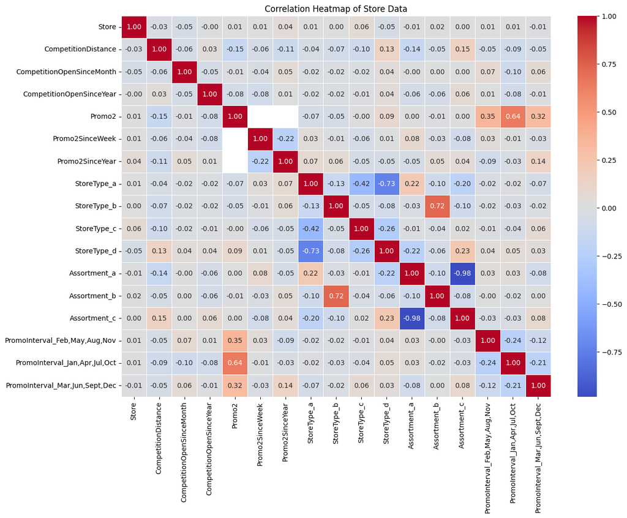

```python
#One-Hot-Encoding for StoreType, Assortment, PromoInterval
store_encoded = pd.get_dummies(df_store, columns=['StoreType', 'Assortment', 'PromoInterval'])

# Correlation matrix for train data
store_correlation_matrix = store_encoded.corr()

# Plotting the correlation heatmap
plt.figure(figsize=(14, 10))
sns.heatmap(store_correlation_matrix, annot=True, cmap='coolwarm', fmt='.2f', linewidths=0.5)
plt.title('Correlation Heatmap of Store Data')
plt.show()
```

## Korrelation zwischen den Datensätzen Training und Store

Für die weitere Analyse der Verkäufe in den Rossmann Filialen werden der Trainingsdatensatz und das Store-Datensatz zu einem Dataframe zusammengeführt. Diese Untersuchung soll zeigen, ob die Verkäufe oder Kundenanzahl von der Wettberwerbsdistanz, dauerhaften Promotionen, Ladentypen, Sortimenten und Promotionsintervallen abhängig sind. Zunächst müssen, wie bei den vorherigen Matrizen, die Variablen `StateHoliday`, `StoreType`, `Assortment` und `PromoInterval` durch One-Hot-Encoding entschlüsselt werden.

Die Korrelationsmatrix zeigt, dass die Distanz zu einem Wettberwerber-Filiale sowie `Promo2` eine schwach negative Korrelation zu der Kundenanzahl aufweist. Des Weiteren korreliert die Kundenanzahl schwach positiv mit dem `StoreType_b` und dem `Assortment_b`, während die Kundenanzahl mit `StoreType_d` schwach negativ korreliert. Die Verkäufe zeigen mit dem `StoreType_b` ebenfalls eine schwach positive Korrelation auf.

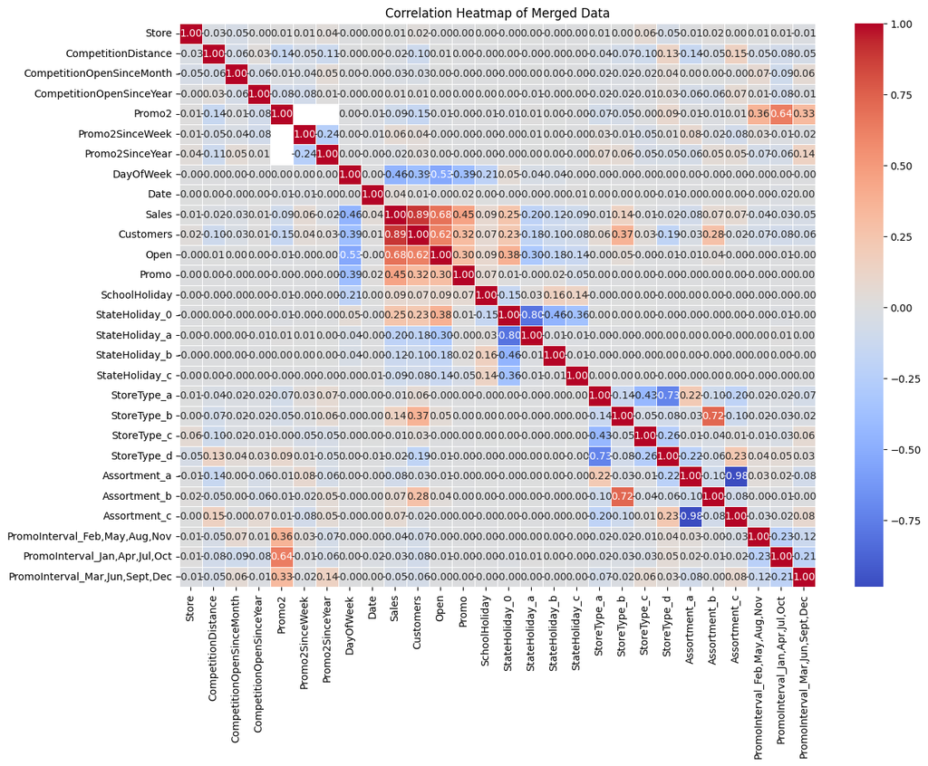

```python
df_merged = pd.merge(df_store, df_train, on='Store')

#One-Hot-Encoding for StateHoliday, StoreTypes, Assortment, PromoInterval
merged_encoded = pd.get_dummies(df_merged, columns=['StateHoliday', 'StoreType', 'Assortment', 'PromoInterval'])

# Correlation matrix for train data
merged_correlation_matrix = merged_encoded.corr()

# Plotting the correlation heatmap
plt.figure(figsize=(14, 10))
sns.heatmap(merged_correlation_matrix, annot=True, cmap='coolwarm', fmt='.2f', linewidths=0.5)
plt.title('Correlation Heatmap of Merged Data')
plt.show()
```

```python
df_merged.head()
```

|  | Store | StoreType | Assortment | CompetitionDistance | CompetitionOpenSinceMonth | CompetitionOpenSinceYear | Promo2 | Promo2SinceWeek | Promo2SinceYear | PromoInterval | DayOfWeek | Date | Sales | Customers | Open | Promo | StateHoliday | SchoolHoliday |
| --- | --- | --- | --- | --- | --- | --- | --- | --- | --- | --- | --- | --- | --- | --- | --- | --- | --- | --- |
| 0 | 1 | c | a | 1270 | 9 | 2008 | 0 | <NA> | <NA> | NaN | 5 | 2015-07-31 | 5263 | 555 | 1 | 1 | 0 | 1 |
| 1 | 1 | c | a | 1270 | 9 | 2008 | 0 | <NA> | <NA> | NaN | 4 | 2015-07-30 | 5020 | 546 | 1 | 1 | 0 | 1 |
| 2 | 1 | c | a | 1270 | 9 | 2008 | 0 | <NA> | <NA> | NaN | 3 | 2015-07-29 | 4782 | 523 | 1 | 1 | 0 | 1 |
| 3 | 1 | c | a | 1270 | 9 | 2008 | 0 | <NA> | <NA> | NaN | 2 | 2015-07-28 | 5011 | 560 | 1 | 1 | 0 | 1 |
| 4 | 1 | c | a | 1270 | 9 | 2008 | 0 | <NA> | <NA> | NaN | 1 | 2015-07-27 | 6102 | 612 | 1 | 1 | 0 | 1 |

# Pairplot

Ein Pairplot wird bei einer deskriptiven Analyse verwendet, um die Beziehungen zwischen verschiedenen Variablen in einem Datensatz visuell zu untersuchen. Daher werden die gegebenen Variablen auf deren Beziehung zueinander untersucht. Ein Pairplot zeigt für jede mögliche Kombination von Variablenpaaren in einem Datensatz eine Streudiagrammmatrix und ermöglicht so eine schnelle visuelle Einsicht in die Datenstruktur. Es ist besonders nützlich, um erste Hypothesen zu überprüfen oder um die Grundlage für weitere fortgeschrittene Analysen zu legen. (Seaborn, o.D.)

Der Pairplot zeigt verschiedene Beziehungen zwischen den gegebenen Variablen (`Customers`, `Sales`, `CompetitionDistance`, `CompetitionOpenSinceYear`, `DayOfWeek`) und bietet Einblicke in ihre Verteilungen und Korrelationen. Nachfolgend werden einzelne Beziehung und Verteilungen beschrieben:

1. Beziehung zwischen `Customers` und `Sales`:
   - Es gibt eine deutlich positive Korrelation zwischen der Anzahl der Kunden und dem Umsatz. Das bedeutet, dass ein Anstieg der Kundenzahl in der Regel mit einem Anstieg des Umsatzes einhergeht.
   - Es liegt eine lineare Beziehung vor, was darauf hinweist, dass die meisten Geschäfte mehr Umsatz machen, wenn sie mehr Kunden haben.
2. Verteilungen:
   - Diagonale KDE-Plots: Die diagonalen Plots zeigen die Kernel-Density-Estimates (KDE) der Verteilungen für jede Variable. KDE ist eine Methode zur Schätzung der Wahrscheinlichkeitsdichte einer Zufallsvariablen basierend auf einer Stichprobe von Daten. Vereinfacht gesagt, stellt KDE eine glatte Schätzung der Wahrscheinlichkeitsverteilung der Daten dar, indem es um jeden Datenpunkt herum eine sogenannte Kernfunktion platziert und dann diese Funktionen summiert, um eine kontinuierliche Schätzung zu erzeugen.
   - `Customers`: Die Kundenanzahl zeigt eine schiefe Verteilung, wobei die meisten Geschäfte eine relativ geringe Anzahl von Kunden haben. Einige Ausreißer mit sehr hohen Kundenzahlen sind ebenfalls erkennbar.
   - `Sales`: Der Umsatz weist eine ähnliche Verteilung auf wie die Kundenanzahl, was die positive Korrelation zwischen diesen beiden Variablen weiter bestätigt.
   - `CompetitionDistance`: Diese Variable ist stark schief verteilt, mit den meisten Wettbewerbern in der Nähe und einigen wenigen weit entfernten.
   - `CompetitionOpenSinceYear`: Die Eröffnungsjahre der Wettbewerber sind breit verteilt, was darauf hinweist, dass einige Wettbewerber schon lange auf dem Markt sind, während andere erst kürzlich eröffnet wurden.
   - `DayOfWeek`: Die Verteilung der Wochentage ist gleichmäßig, da jeder Tag der Woche (1-7) in ähnlicher Häufigkeit vorkommt.
3. Weitere Beziehungen:
   - `Customers` vs. `CompetitionDistance`: Es gibt keine klare Korrelation zwischen der Anzahl der Kunden und der Entfernung zum nächsten Wettbewerber.
   - `Sales` vs. `CompetitionDistance`: Ähnlich wie bei den Kunden zeigt auch der Umsatz keine deutliche Korrelation mit der Wettbewerbsentfernung.
   - `Customers` vs. `CompetitionOpenSinceYear`: Es ist keine klare Beziehung zwischen der Anzahl der Kunden und dem Eröffnungsjahr der Wettbewerber erkennbar.
   - `Sales` vs. `CompetitionOpenSinceYear`: Auch hier gibt es keine deutliche Korrelation.
   - `Customers` vs. `DayOfWeek`: Die Anzahl der Kunden variiert je nach Wochentag, wobei einige Tage tendenziell mehr Kunden anziehen.
   - `Sales` vs. `DayOfWeek`: Der Umsatz variiert ebenfalls je nach Wochentag, was wahrscheinlich mit der Kundenanzahl zusammenhängt.

Insgesamt zeigt der Pairplot wichtige Korrelationen, insbesondere zwischen der Anzahl der Kunden und dem Umsatz, während andere Variablen wie die Entfernung zum Wettbewerb und das Eröffnungsjahr der Wettbewerber weniger Einfluss auf Kundenanzahl und Umsatz zu haben scheinen. Die gleichmäßige Verteilung der Wochentage bietet keine zusätzlichen Insights bezüglich der anderen Variablen.

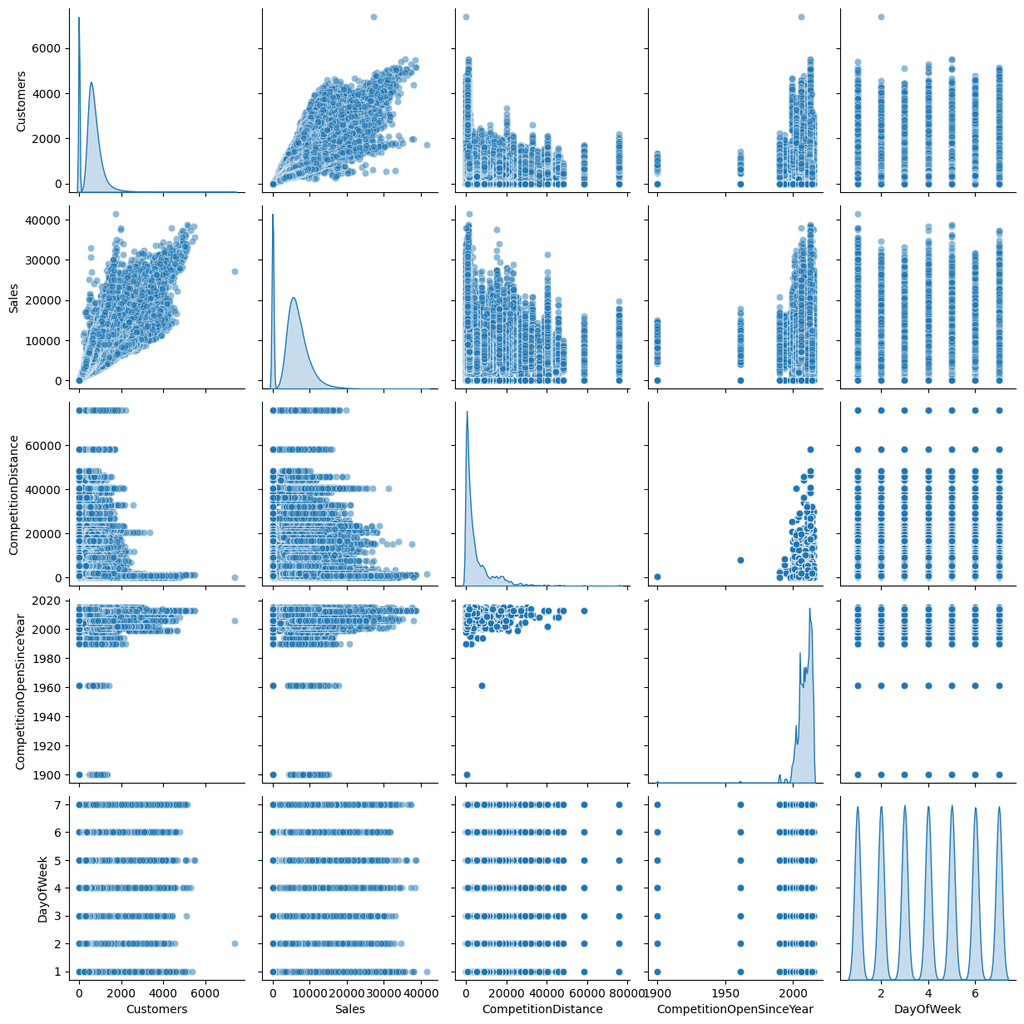

```python
# Select column for pairplot
selected_columns = ['Customers', 'Sales', 'CompetitionDistance', 'CompetitionOpenSinceYear', 'DayOfWeek', 'Date']

sns.pairplot(df_merged[selected_columns], diag_kind='kde', plot_kws={'alpha':0.5})
plt.show()
```

# Boxplots

Im folgenden werden Boxplots verwendet, um die Verteilung von Sales in Bezug auf die kategorischen Daten `StoreType`, `Assortment`, `Promo2`, `Open`, `Promo`, `PromoInterval`, `DayOfWeek`, `StateHoliday` und `SchoolHoliday` zu visualisieren und die Unterschiede zwischen den verschiedenen Kategorien zu erkennen.

## Boxplot Sales & StoreType

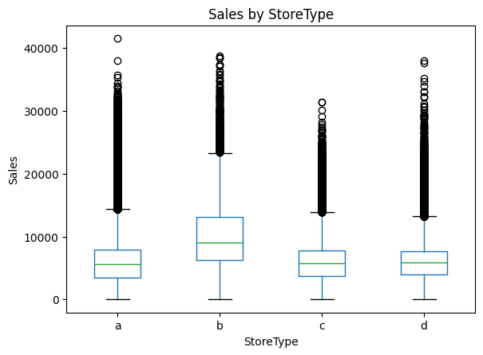

```python
# Boxplots erstellen
plt.figure(figsize=(10, 6))
df_merged.boxplot(column='Sales', by='StoreType', grid=False)
plt.title('Sales by StoreType')
plt.suptitle('')  # Entfernt den Standard-Titel
plt.xlabel('StoreType')
plt.ylabel('Sales')
plt.show()
```

## Boxplot Sales & Assortment

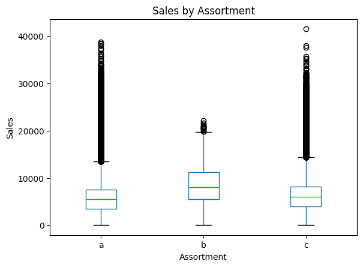

```python
plt.figure(figsize=(10, 6))
df_merged.boxplot(column='Sales', by='Assortment', grid=False)
plt.title('Sales by Assortment')
plt.suptitle('')  # Entfernt den Standard-Titel
plt.xlabel('Assortment')
plt.ylabel('Sales')
plt.show()
```

## Boxplot Sales & Promo2

Der Plot zeigt die Verteilung der Verkaufszahlen (`Sales`) pro Tag in Bezug auf die Stores die eine Langzeit-Promoaktion (`Promo2` = 1) laufen haben. Die Teilnahme an `Promo2` ist tendenziell mit leicht niedrigeren Median-Verkaufszahlen verbunden, jedoch weisen beide Gruppen eine ähnliche Varianz und Verteilung der Verkaufszahlen auf. Die Anzahl der Ausreißer ist in beiden Gruppen hoch, was auf Tage mit außergewöhnlich hohen Verkaufszahlen hinweist.

```python
df_merged[df_merged['Promo2'] == 0]['Sales'].median()
```

```
6038.0
```

```python
df_merged[df_merged['Promo2'] == 1]['Sales'].median()
```

```
5478.0
```

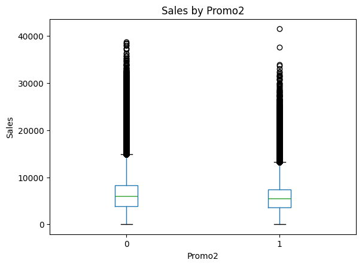

```python
plt.figure(figsize=(10, 6))
df_merged.boxplot(column='Sales', by='Promo2', grid=False)
plt.title('Sales by Promo2')
plt.suptitle('')  # remove title
plt.xlabel('Promo2')
plt.ylabel('Sales')
plt.show()
```

## Boxplot Sales & PromoInterval

Der Boxplot zeigt die Verteilung der Verkaufszahlen (`Sales`) in Bezug auf verschiedene `PromoIntervals`. Die `PromoIntervals` sind die Monate, in denen die Promotionen stattfinden, und sind in die drei folgenden Gruppen unterteilt: (Feb,May,Aug,Nov), (Jan,Apr,Jul,Oct), (Mar,Jun,Sept,Dec). Die Mediane, IQRs und Whiskers sind bei allen `PromoIntervals` sehr ähnlich, sodass man von einer vergleichbaren Verteilung ausgehen kann. Des Weiteren weisen alle drei Intervalle eine Vielzahl an Ausreißern auf. Zusammengefasst zeigt der Plot, dass die verschiedenen `PromoIntervals` in Bezug auf die Verkaufszahlen keine großen Unterschiede aufweisen. Die Mediane, IQRs und die Verteilung der Daten sind sehr ähnlich, was darauf hindeutet, dass die Verkaufszahlen über die verschiedenen `PromoIntervals` hinweg relativ gleichmäßig verteilt sind.

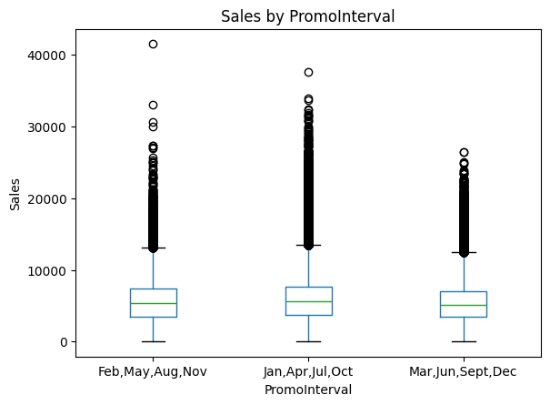

```python
plt.figure(figsize=(10, 6))
df_merged.boxplot(column='Sales', by='PromoInterval', grid=False)
plt.title('Sales by PromoInterval')
plt.suptitle('')  # Entfernt den Standard-Titel
plt.xlabel('PromoInterval')
plt.ylabel('Sales')
plt.show()
```

## Boxplot Sales & DayOfWeek

Der Boxplot zeigt die Verteilung der Verkaufszahlen (`Sales`) in Bezug auf den `DayOfWeek`, wobei die Tage von 1 bis 7 nummeriert sind (Montag bis Sonntag). Der Median und IQR der Verkaufszahlen ist für die Tage 1 bis 6 relativ ähnlich, wobei Tag 1 (Montag) tendenziell den höchsten Median aufweist, gefolgt von Tag 2 (Dienstag), 5 (Freitag), 3 (Mittwoch), 4 (Donnerstag) und 6 (Samstag). Tag 7 (Sonntag) hingegen hat somit mit 0 `Sales` einen deutlich niedrigeren Median als die anderen Tage und folglich niedrige Verkaufszahlen. An den Tagen 1 bis 6 gibt es zahlreiche Ausreißer, was auf einzelne Tage mit sehr hohen Verkaufszahlen hinweist. An Tag 7 (Sonntag) gibt es ebenfalls Ausreißer, aber insgesamt sind die Verkaufszahlen deutlich niedriger. Zusammengefasst zeigt der Plot, dass die Verkaufszahlen an den Tagen 1 bis 6 relativ ähnlich sind, mit tendenziell höheren Verkaufszahlen an Montag, Dienstag und Freitag. Der Sonntag hat jedoch deutlich niedrigere Verkaufszahlen und eine geringere Variabilität. Dies deutet darauf hin, dass die Geschäfte an Sonntagen entweder geschlossen sind oder signifikant weniger Umsatz generieren.

```python
df_merged[df_merged['DayOfWeek'] == 1]['Sales'].median()
```

```
7310.0
```

```python
df_merged[df_merged['DayOfWeek'] == 2]['Sales'].median()
```

```
6463.0
```

```python
df_merged[df_merged['DayOfWeek'] == 3]['Sales'].median()
```

```
6133.0
```

```python
df_merged[df_merged['DayOfWeek'] == 4]['Sales'].median()
```

```
6020.0
```

```python
df_merged[df_merged['DayOfWeek'] == 5]['Sales'].median()
```

```
6434.0
```

```python
df_merged[df_merged['DayOfWeek'] == 6]['Sales'].median()
```

```
5410.0
```

```python
df_merged[df_merged['DayOfWeek'] == 7]['Sales'].median()
```

```
0.0
```

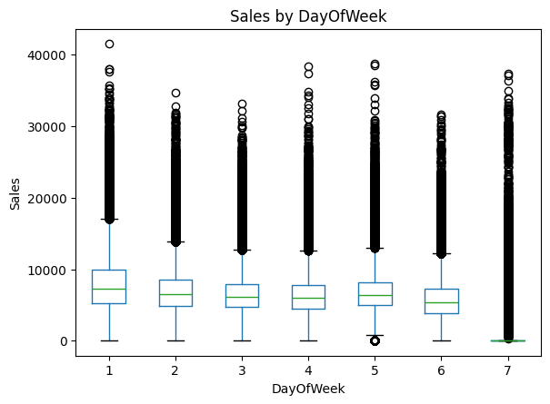

```python
plt.figure(figsize=(10, 6))
df_merged.boxplot(column='Sales', by='DayOfWeek', grid=False)
plt.title('Sales by DayOfWeek')
plt.suptitle('')  # Entfernt den Standard-Titel
plt.xlabel('DayOfWeek')
plt.ylabel('Sales')
plt.show()
```

## Boxplot Sales & Open

Der Boxplot zeigt die Verteilung der Verkaufszahlen (`Sales`) in Bezug auf den `Open`-Status der Geschäfte, wobei 0 bedeutet, dass das Geschäft geschlossen ist, und 1 bedeutet, dass das Geschäft geöffnet ist. Den Boxplots ist zu entnehmen, dass die Verkaufszahlen erwartungsgemäß bei 0 liegen, wenn die Geschäfte geschlossen sind (`Open` = 0). Zudem sind keine nennenswerten Ausreißer für `Open` = 0 zu erkennen. Wenn die Geschäfte geöffnet sind (`Open` = 1), gibt es einen deutlich höhereren Median mit 6.369 Sales/Tag und einer Reihe an Ausreißern, was auf einzelne Tage mit sehr hohen Verkaufszahlen (bis zu 41.551/Tag) hinweist. Zusammengefasst zeigt der Plot, dass die Verkaufszahlen bei geschlossenen Geschäften (`Open` = 0) konsistent bei 0 liegen. Bei geöffneten Geschäften (`Open` = 1) gibt es eine signifikante Variabilität und eine Reihe von Tagen mit sehr hohen Verkaufszahlen. Der Unterschied zwischen geöffneten und geschlossenen Geschäften ist sehr deutlich und zeigt, wie wichtig der Öffnungsstatus für die Verkaufszahlen ist.

```python
df_merged[df_merged['Open'] == 1]['Sales'].max()
```

```
41551
```

```python
df_merged[df_merged['Open'] == 1]['Sales'].median()
```

```
6369.0
```

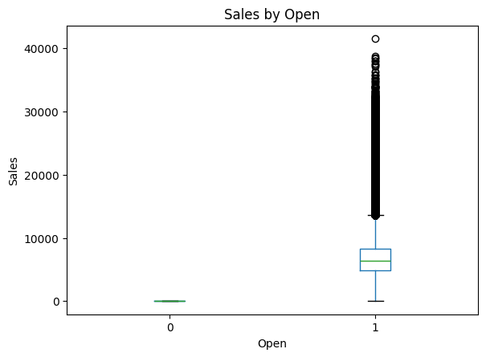

```python
plt.figure(figsize=(10, 6))
df_merged.boxplot(column='Sales', by='Open', grid=False)
plt.title('Sales by Open')
plt.suptitle('')  # Entfernt den Standard-Titel
plt.xlabel('Open')
plt.ylabel('Sales')
plt.show()
```

## Boxplot Sales & Promo

Der Boxplot zeigt die Verteilung der Verkaufszahlen (`Sales`) in Bezug auf den Einsatz von tagesbezogenen Promoaktionen. Wobei `Promo` = 1 für "mit Promo" und `Promo` = 0 für "ohne Promo" steht. Der Median ist bei `Promo` = 1 (mit Promotion) höher als bei `Promo` = 0 (ohne Promotion). Dies deutet darauf hin, dass die Verkaufszahlen während Promotionen tendenziell höher sind. Die mittleren 50% der Daten bei aktiver Promo liegen im Gegensatz zu ohne Promo in einem kleineren Bereich, sind jedoch im Vergleich höher. Jedoch ist die Varianz der Daten für `Promo` = 0 größer. Beide Gruppen haben zahlreiche Ausreißer, was auf einzelne Tage mit sehr hohen Verkaufszahlen hinweist. Zusammengefasst zeigt der Boxplot, dass Promotionen tendenziell höhere Median-Verkaufszahlen bringen, wobei die Varianz der Verkaufszahlen ohne Promotionen höher ist.

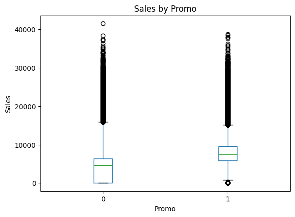

```python
plt.figure(figsize=(10, 6))
df_merged.boxplot(column='Sales', by='Promo', grid=False)
plt.title('Sales by Promo')
plt.suptitle('')  # Entfernt den Standard-Titel
plt.xlabel('Promo')
plt.ylabel('Sales')
plt.show()
```

## Boxplot Sales & StateHoliday

Der Boxplot zeigt die Verteilung der Verkaufszahlen (`Sales`) in Bezug auf verschiedene staatliche Feiertage (0: Kein Feiertag, a: Gesetzlicher Feiertag, b: Osterferien, c: Weihnachten).

Der Median der Verkaufszahlen ist bei 0 (kein Feiertag) mit 5.849 Sales/ Tag deutlich höher als bei den Feiertagskategorien a, b und c mit 0 Sales/Tag, was darauf hindeutet, dass die Verkaufszahlen an normalen Tagen höher sind und eine größere Varianz aufweisen. Für 0 gibt es viele Ausreißer, was auf Tage mit sehr hohen Verkaufszahlen hinweist. Für a, b und c gibt es ebenfalls Ausreißer, wobei an Ostern und Weihnachten weniger Ausreißer existieren als für andere gesetzliche Feiertage. Zusammengefasst zeigt der Plot, dass die Verkaufszahlen an normalen Tagen (0) deutlich höher und variabler sind als an Feiertagen (a, b und c). An Feiertagen sind die Verkaufszahlen konsistent niedriger, was wahrscheinlich darauf zurückzuführen ist, dass viele Geschäfte an diesen Tagen geschlossen sind oder weniger Kundenverkehr haben.

```python
df_merged[df_merged['StateHoliday'] == '0']['Sales'].median()
```

```
5849.0
```

```python
df_merged[df_merged['StateHoliday'] == 'a']['Sales'].median()
```

```
0.0
```

```python
df_merged[df_merged['StateHoliday'] == 'b']['Sales'].median()
```

```
0.0
```

```python
df_merged[df_merged['StateHoliday'] == 'c']['Sales'].median()
```

```
0.0
```

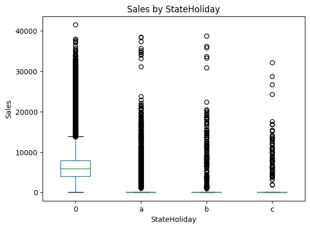

```python
plt.figure(figsize=(10, 6))
df_merged.boxplot(column='Sales', by='StateHoliday', grid=False)
plt.title('Sales by StateHoliday')
plt.suptitle('')  # Entfernt den Standard-Titel
plt.xlabel('StateHoliday')
plt.ylabel('Sales')
plt.show()
```

## Boxplot Sales & SchoolHoliday

Der Boxplot zeigt die Verteilung der Verkaufszahlen (`Sales`) in Bezug auf `SchoolHoliday`, wobei 0 bedeutet, dass es kein Schulferien-Tag ist, und 1 bedeutet, dass es ein Schulferien-Tag ist. Der Median der Verkaufszahlen ist bei 0 (kein Schulferien-Tag) und 1 (Schulferien-Tag) ähnlich, was darauf hinweist, dass Schulferien keine signifikante Auswirkung auf den Median der Verkaufszahlen haben. Beide Gruppen haben zahlreiche Ausreißer, was auf einzelne Tage mit sehr hohen Verkaufszahlen hinweist, jedoch sind die Anzahl und Höhe der Ausreißer bei beiden Gruppen auch ähnlich. Dies deutet darauf hin, dass die allgemeine Verteilung der Verkaufszahlen durch Schulferien nicht stark beeinflusst wird. Zusammengefasst zeigt der Plot, dass Schulferien (`SchoolHoliday`) keine signifikante Auswirkung auf die Verteilung oder die Höhe der Verkaufszahlen haben. Die Mediane, IQRs und die Verteilung der Daten sind für beide Gruppen vergleichbar.

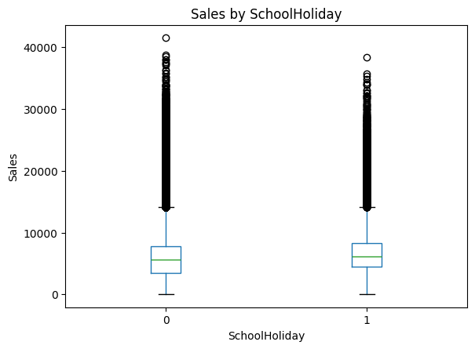

```python
plt.figure(figsize=(10, 6))
df_merged.boxplot(column='Sales', by='SchoolHoliday', grid=False)
plt.title('Sales by SchoolHoliday')
plt.suptitle('')  # Entfernt den Standard-Titel
plt.xlabel('SchoolHoliday')
plt.ylabel('Sales')
plt.show()
```

# Fazit

Die deskriptive Analyse des Rossmann Store Sales Datensatzes zeigt, dass in dem Store- und Test-Datensatz fehlerhafte Werte vorliegen. Beim Test-Datensatz sind elf Werte in der Spalte `Open` fehlerhaft, während im Store-Datensatz 2.343 fehlerhafte Werte in den Spalten `CompetitionDistance`, `CompetitionOpenSinceMonth`, `CompetitionDistanceYear`, `Promo2SinceWeek`, `Promo2SinceYear` und `PromoInterval` vorliegen. Bevor die Modelle erstellt werden können, müssen diese fehlerhaften Werte bereinigt werden, um genaue Vorhersagen zu gewährleisten. Der Trainingsdatensatz beinhaltet über eine Million Einträge und stellt somit einen ausreichend großen Datensatz für die Erstellung von Regessionmodellen dar.

Aus den Korrelationsmatrizen und den Boxplot können Abhängigkeiten zwischen den Merkmalen der Datensätze festegestellt werden. Um die qualitativen Merkmale in den Korrelationsmatrizen darzustellen, wurden diese mittels One-Hot-Encoding binär codiert. Jedoch muss an dieser Stelle erwähnt werden, dass die binäre Darstellung für qualitative Merkmale nicht geeignet ist, da die Beziehungen zwischen den Werten eines Merkmals verloren gehen. Aufgrund dessen werden die Beziehungen in Boxplots überprüft und analysiert.

Der Pairplot bestätigt hierbei die starke Korrelation zwischen `Sales` und `Customers`, was zu erwarten war, da ohne Kunden keine Verkäufe stattfinden können. Es liegt keine Korrelation zwischen der Kundenanzahl und der Entfernung zur nächsten Wettberwerber-Filiale, ebenso wenig wie zwischen den Verkaufszahlen und der Entfernung zum Wettbewerber vor.

Abschließend lässt sich feststellen, dass es sich bei diesem Rossmann Store Sales Datensatz um eine Zeitreihe handelt und die Analyse ein Regressionsproblem darstellt. Die Tatsache, dass es sich um eine Zeitreihe handelt, muss bei der Erstellung von Modellen für die Vorhersage der Verkäufe der nächsten sechs Wochen berücksichtigt werden.

# Quellen

Dirk Rossmann GmbH (o.D.): ROSSMANN von 1972 bis heute. Online unter: https://unternehmen.rossmann.de/ueber-uns/unsere-geschichte.html. Letzter Zugriff am 20.06.2024.

Kaggle (o.D.): Rossmann Store Sales. Online unter: https://www.kaggle.com/competitions/rossmann-store-sales/overview. Letzter Zugriff am 23.06.2024.

Microsoft Coorperation (o.D.): Datentyp: Zusammenfassung (Visual Basic). Online unter: https://learn.microsoft.com/de-de/dotnet/visual-basic/language-reference/data-types/. Letzter Zugriff am 19.06.2024.

Seaborn (o.D.): seaborn.pairplot. Online unter: https://seaborn.pydata.org/generated/seaborn.pairplot.html. Letzter Zugriff am 24.06.2024.